## 1 Sampling unique IDs and basic statistics

This code is designed for users with a basic understanding of R programming, and provides a comprehensive guide to generating unique site IDs for the previously created sampling design, as well as an overview of the point distribution.

Ensure you have the `tinytex`, `knitr`, `rmarkdown`, and `rstudioapi` R packages installed to successfully run and render R Markdown documents before running this script. Additionally, install `tinytex::install_tinytex()` by running `tinytex::install_tinytex()` to enable LaTeX support for PDF generation.

### 1.1 Setting up the environment and loading libraries

First, set the working directory to the location of your R script. This ensures that all paths in the script are relative to the script’s location.

```r
setwd(dirname(rstudioapi::getActiveDocumentContext()$path))
setwd("../") # Move wd down to the main folder
getwd()
```

```
## [1] "D:/FAO/github/SoilFER/sampling design"
```

### 1.2 Install required libraries

The script uses several R libraries, each serving a specific purpose. Below is a quick summary of the key functions of these libraries:

Summary of required R libraries and their purposes

| Package | Purpose |
| --- | --- |
| sp | Handling spatial data and performing geographic operations. |
| terra | Working with raster and vector spatial data, including transformations and analyses. |
| sf | Modern and efficient library for handling vector spatial data. |
| data.table | Efficient data manipulation and aggregation for large datasets. |
| dplyr | Data manipulation and transformation. |
| ggplot2 | Data visualization using the grammar of graphics. |
| RColorBrewer | Providing color palettes for visualizations. |

First step is to load all required R libraries. An alternative and beginner-friendly way of install R packages using RStudio is through the **Packages** tab in RStudio. First of all, locate this tab in the bottom-right pane of RStudio and click on it. Then, click the *Install* button at the top of the tab. In the dialog box that appears, type the name of the package (e.g., `data.table`) in the text field. Make sure that *Install dependencies* box is checked, and finally, click *Install* to download and install the package.

```r
packages <- c("sp", "terra", "sf", "data.table", "dplyr", "ggplot2", "RColorBrewer")

invisible(lapply(packages, library, character.only = TRUE))

rm(packages)
```

### 1.3 Define variables, and parameters

Several variables and parameters must be defined to establish a consistent framework for the script.

The `ISO.code` variable is used to define the unique [Alpha-3 ISO code](https://www.iso.org/obp/ui/#search) of the country of interest. This standard ensures consistency when naming variables and file paths throughout the script.

```r
ISO.code <- "ZMB"
```

> 💡**Note**: In this example, **“ZMB”** is used as the ISO code for Zambia.

The `epsg` variable specifies the coordinate reference system used for spatial data. EPSG codes are globally recognized standards for geospatial datasets. If you do not have this information, you can search [here](https://epsg.io/).

```r
epsg <- "EPSG:3857"
```

This section sets the file paths for accessing data such as raster files, shapefiles, and other resources. Additionally, it ensures the creation of a results folder for storing processed files related to the specified land use. Organizing file paths ensures that all resources and results are systematically stored and accessed.

```r
# Define folder location
folder <- "data/results/"

# Create folder location for all data
folder_all <- paste0(folder,"all/")

# check if folder_all directory exists if not create it
if (!file.exists(folder_all)){
  # create a new sub directory inside the main path
  dir.create(folder_all)
}
```

### 1.4 Importing and merging the sampling unit files

After defining the variables and parameters, the next step is to import the shapefiles containing the Primary Sampling Units (PSUs) and Tertiary Sampling Units (TSUs) for one or more land-use types. This procedure enables users to work with the sampling units associated with different land-use categories such as croplands, grasslands, or forests.

If working with multiple land-use types, replicate the code lines for importing files and ensure you correctly specify the file paths and object names for each land-use type. Below is an example for croplands:

```r
# PSUs
psus_target_croplands <- sf::st_read(paste0(folder, "crops/PSUs_target.shp"), quiet = T)
psus_target_croplands$lulc <- "C"
psus_target_croplands
```

```
## Simple feature collection with 26 features and 3 fields
## Geometry type: POLYGON
## Dimension:     XY
## Bounding box:  xmin: 3377974 ymin: -1615992 xmax: 3529974 ymax: -1497992
## Projected CRS: WGS 84 / Pseudo-Mercator
## First 10 features:
##      ID Replace_ID                       geometry lulc
## 1   468        270 POLYGON ((3449974 -1615992,...    C
## 2   639        275 POLYGON ((3447974 -1611992,...    C
## 3   712        282 POLYGON ((3421974 -1609992,...    C
## 4   715        271 POLYGON ((3427974 -1609992,...    C
## 5  1384        265 POLYGON ((3389974 -1593992,...    C
## 6  1442        278 POLYGON ((3505974 -1593992,...    C
## 7  1453        273 POLYGON ((3527974 -1593992,...    C
## 8  1496        264 POLYGON ((3441974 -1591992,...    C
## 9  1570        287 POLYGON ((3417974 -1589992,...    C
## 10 2308        263 POLYGON ((3517974 -1573992,...    C
```

```r
# TSUs
tsus_target_croplands <- sf::st_read(paste0(folder, "crops/TSUs_target.shp"), quiet = T)
tsus_target_croplands$lulc <- "C"
tsus_target_croplands
```

```
## Simple feature collection with 546 features and 12 fields
## Geometry type: POINT
## Dimension:     XY
## Bounding box:  xmin: 3377982 ymin: -1615889 xmax: 3529974 ymax: -1498011
## Projected CRS: WGS 84 / Pseudo-Mercator
## First 10 features:
##    TSU_Name PSU_ID SSU_ID TSU_ID PSU_Type SSU_Type    TSU_Type  ID Replace_ID
## 1  468.61.1    468     61      1   Target   Target      Target 468        270
## 2  468.61.2    468     61      2   Target   Target Alternative 468        270
## 3  468.61.3    468     61      3   Target   Target Alternative 468        270
## 4  468.35.1    468     35      1   Target   Target      Target 468        270
## 5  468.35.2    468     35      2   Target   Target Alternative 468        270
## 6  468.35.3    468     35      3   Target   Target Alternative 468        270
## 7  468.44.1    468     44      1   Target   Target      Target 468        270
## 8  468.44.2    468     44      2   Target   Target Alternative 468        270
## 9  468.44.3    468     44      3   Target   Target Alternative 468        270
## 10 468.41.1    468     41      1   Target   Target      Target 468        270
##    order    site_id                 geometry lulc
## 1      1 ZMB468-1-1 POINT (3451411 -1614238)    C
## 2      1 ZMB468-1-2 POINT (3451432 -1614195)    C
## 3      1 ZMB468-1-3 POINT (3451411 -1614216)    C
## 4      2 ZMB468-2-1 POINT (3450113 -1614852)    C
## 5      2 ZMB468-2-2 POINT (3450154 -1614830)    C
## 6      2 ZMB468-2-3 POINT (3450133 -1614830)    C
## 7      3 ZMB468-3-1 POINT (3450319 -1614682)    C
## 8      3 ZMB468-3-2 POINT (3450298 -1614661)    C
## 9      3 ZMB468-3-3 POINT (3450339 -1614619)    C
## 10     4 ZMB468-4-1 POINT (3450628 -1614725)    C
```

> 💡**Note**: The `lulc` field is used to assign a unique label for the land-use type (e.g., “C” for croplands). Ensure consistency in naming across your dataset.

If you are working with multiple land-use types, you will need to merge the sampling unit files (PSUs and TSUs) from all categories. This step consolidates the data for easier processing and visualization. However, if you only have one land-use type, this step is not required.

```r
# PSUs
psus_target_list <- list(psus_target_croplands, psus_target_grasslands, psus_target_forests)
psus_target <- sf::st_as_sf(data.table::rbindlist(psus_target_list))

# TSUs
tsus_target_list <- list(tsus_target_croplands, tsus_target_grasslands, tsus_target_forests)
tsus_target <- sf::st_as_sf(data.table::rbindlist(tsus_target_list))
```

> 💡**Note**: When merging files, ensure that the field names and data structure are consistent across all shapefiles. Otherwise, the merge may fail or produce incorrect results.

The same process applied steps before for the target sampling units applies to alternative or replacement sampling units.

```r
# PSUs
psus_repl_croplands <- sf::st_read(paste0(folder, "crops/PSUs_replacements.shp"), quiet = T)
psus_repl_croplands$lulc <- "C"

# TSUs
tsus_repl_croplands <- sf::st_read(paste0(folder, "crops/TSUs_replacements.shp"), quiet = T)
tsus_repl_croplands$lulc <- "C"
```

If working with multiple land-use types, merge the replacement files as shown below:

```r
# PSUs
psus_repl_list <- list(psus_repl_croplands, psus_repl_grasslands, psus_repl_forests)
psus_repl <- sf::st_as_sf(data.table::rbindlist(psus_repl_list))

# TSUs
tsus_repl_list <- list(tsus_repl_croplands, tsus_repl_grasslands, tsus_repl_forests)
tsus_repl <- sf::st_as_sf(data.table::rbindlist(tsus_repl_list))
```

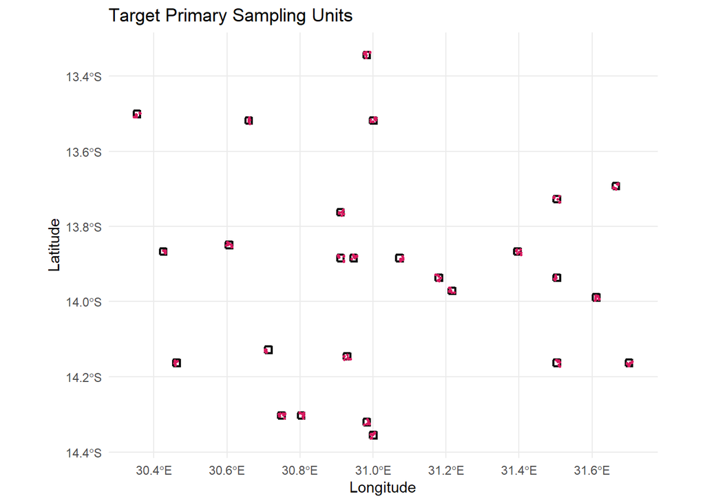

```r
ggplot() +
  geom_sf(data = psus_target_croplands, color = "#101010", fill = NA, lwd = 0.8) +
  geom_sf(data = tsus_target_croplands, aes(), color = "#D81B60", size = 0.5, shape = 19, lwd = 0.7) +
  labs(title = "Target Primary Sampling Units",
       x = "Longitude",
       y = "Latitude",
       fill = "PC1") +
  theme_minimal()
```

>

💡**Note**: Use the individual objects (`psus_target_croplands` and `tsus_target_croplands`) for visualization when working with a single land-use type. For multiple land-use types, replace these with the merged objects (`psus_target` and `tsus_target`)

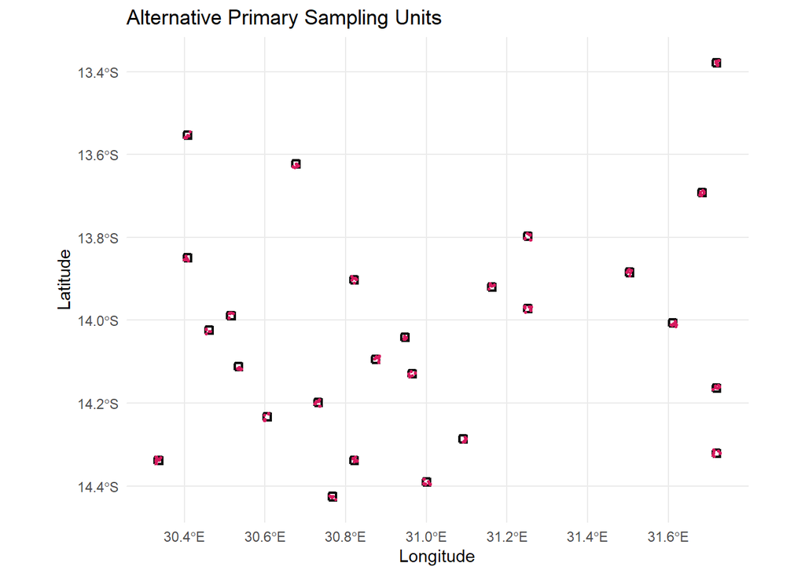

```r
ggplot() +
  geom_sf(data = psus_repl_croplands, color = "#101010", fill = NA, lwd = 0.8) +
  geom_sf(data = tsus_repl_croplands, aes(), color = "#D81B60", size = 0.5, shape = 19, lwd = 0.7) +
  labs(title = "Alternative Primary Sampling Units",
       x = "Longitude",
       y = "Latitude",
       fill = "PC1") +
  theme_minimal()
```

>

💡**Note**: Use the individual objects (`psus_repl_croplands` and `tsus_repl_croplands`) for visualization when working with a single land-use type. For multiple land-use types, replace these with the merged objects (`psus_repl` and `tsus_repl`)

### 1.5 Assign unique site ID

This section describes the step-by-step process for creating unique IDs for each site or so called TSU. These IDs ensure consistency and traceability throughout the sampling process.

To begin, we examine the first few entries in the `psus_target_croplands` object to understand its structure. This dataset represents PSUs selected for sampling in cropland areas. If multiple land-use types are involved, use the merged `psus_target` object instead.

```r
head(psus_target_croplands, 5)
```

```
## Simple feature collection with 5 features and 3 fields
## Geometry type: POLYGON
## Dimension:     XY
## Bounding box:  xmin: 3389974 ymin: -1615992 xmax: 3451974 ymax: -1591992
## Projected CRS: WGS 84 / Pseudo-Mercator
##     ID Replace_ID                       geometry lulc
## 1  468        270 POLYGON ((3449974 -1615992,...    C
## 2  639        275 POLYGON ((3447974 -1611992,...    C
## 3  712        282 POLYGON ((3421974 -1609992,...    C
## 4  715        271 POLYGON ((3427974 -1609992,...    C
## 5 1384        265 POLYGON ((3389974 -1593992,...    C
```

Here, a key ID (`PSU_R_LULC_ID`) is generated by combining the PSU’s `Replace_ID` and its land-use type (`lulc`).

```r
psus_target_croplands$PSU_R_LULC_ID <- paste0(psus_target_croplands$Replace_ID, "-", psus_target_croplands$lulc)
head(psus_target_croplands, 5)
```

```
## Simple feature collection with 5 features and 4 fields
## Geometry type: POLYGON
## Dimension:     XY
## Bounding box:  xmin: 3389974 ymin: -1615992 xmax: 3451974 ymax: -1591992
## Projected CRS: WGS 84 / Pseudo-Mercator
##     ID Replace_ID                       geometry lulc PSU_R_LULC_ID
## 1  468        270 POLYGON ((3449974 -1615992,...    C         270-C
## 2  639        275 POLYGON ((3447974 -1611992,...    C         275-C
## 3  712        282 POLYGON ((3421974 -1609992,...    C         282-C
## 4  715        271 POLYGON ((3427974 -1609992,...    C         271-C
## 5 1384        265 POLYGON ((3389974 -1593992,...    C         265-C
```

A sequential unique ID is assigned for each PSU based on the total number of PSUs in the country. The IDs are saved under a field with the country ISO code (`ZMB_PSU_ID`).

```r
psus_target_croplands[[paste0(ISO.code,"_PSU_ID")]] = 1:nrow(psus_target_croplands)

psus_target_croplands <- psus_target_croplands %>%
  select(ID, Replace_ID, lulc, PSU_R_LULC_ID, all_of(paste0(ISO.code, "_PSU_ID")), everything())

head(psus_target_croplands, 5)
```

```
## Simple feature collection with 5 features and 5 fields
## Geometry type: POLYGON
## Dimension:     XY
## Bounding box:  xmin: 3389974 ymin: -1615992 xmax: 3451974 ymax: -1591992
## Projected CRS: WGS 84 / Pseudo-Mercator
##     ID Replace_ID lulc PSU_R_LULC_ID ZMB_PSU_ID                       geometry
## 1  468        270    C         270-C          1 POLYGON ((3449974 -1615992,...
## 2  639        275    C         275-C          2 POLYGON ((3447974 -1611992,...
## 3  712        282    C         282-C          3 POLYGON ((3421974 -1609992,...
## 4  715        271    C         271-C          4 POLYGON ((3427974 -1609992,...
## 5 1384        265    C         265-C          5 POLYGON ((3389974 -1593992,...
```

We repeat the same procedure mentioned above for target PSUs on the replacement/alternative PSUs stored in `psus_repl_croplands`. This ensures replacements also have identical key identifiers as the target PSUs.

```r
head(psus_repl_croplands, 5)
```

```
## Simple feature collection with 5 features and 3 fields
## Geometry type: POLYGON
## Dimension:     XY
## Bounding box:  xmin: 3397974 ymin: -1623992 xmax: 3461974 ymax: -1585992
## Projected CRS: WGS 84 / Pseudo-Mercator
##     ID Replace_ID                       geometry lulc
## 1  296        270 POLYGON ((3449974 -1619992,...    C
## 2  817        275 POLYGON ((3459974 -1607992,...    C
## 3  111        282 POLYGON ((3423974 -1623992,...    C
## 4  544        271 POLYGON ((3429974 -1613992,...    C
## 5 1646        265 POLYGON ((3397974 -1587992,...    C
```

Key IDs are generated for alternative PSUs based on their `Replace_ID` and land-use type (`lulc`).

```r
psus_repl_croplands$PSU_R_LULC_ID <- paste0(psus_repl_croplands$Replace_ID, "-", psus_repl_croplands$lulc)
head(psus_repl_croplands, 5)
```

```
## Simple feature collection with 5 features and 4 fields
## Geometry type: POLYGON
## Dimension:     XY
## Bounding box:  xmin: 3397974 ymin: -1623992 xmax: 3461974 ymax: -1585992
## Projected CRS: WGS 84 / Pseudo-Mercator
##     ID Replace_ID                       geometry lulc PSU_R_LULC_ID
## 1  296        270 POLYGON ((3449974 -1619992,...    C         270-C
## 2  817        275 POLYGON ((3459974 -1607992,...    C         275-C
## 3  111        282 POLYGON ((3423974 -1623992,...    C         282-C
## 4  544        271 POLYGON ((3429974 -1613992,...    C         271-C
## 5 1646        265 POLYGON ((3397974 -1587992,...    C         265-C
```

Now, alternative PSUs are assigned IDs sequentially, starting from the last ID used for the target PSUs (`start_id`).

```r
start_id <- nrow(psus_target_croplands) + 1 # Set where the next id has to start from.

psus_repl_croplands[[paste0(ISO.code,"_PSU_ID")]] = start_id:(start_id + nrow(psus_repl_croplands) - 1)

psus_repl_croplands <- psus_repl_croplands %>%
  select(ID, Replace_ID, lulc, PSU_R_LULC_ID, all_of(paste0(ISO.code, "_PSU_ID")), everything())

head(psus_repl_croplands, 5)
```

```
## Simple feature collection with 5 features and 5 fields
## Geometry type: POLYGON
## Dimension:     XY
## Bounding box:  xmin: 3397974 ymin: -1623992 xmax: 3461974 ymax: -1585992
## Projected CRS: WGS 84 / Pseudo-Mercator
##     ID Replace_ID lulc PSU_R_LULC_ID ZMB_PSU_ID                       geometry
## 1  296        270    C         270-C         27 POLYGON ((3449974 -1619992,...
## 2  817        275    C         275-C         28 POLYGON ((3459974 -1607992,...
## 3  111        282    C         282-C         29 POLYGON ((3423974 -1623992,...
## 4  544        271    C         271-C         30 POLYGON ((3429974 -1613992,...
## 5 1646        265    C         265-C         31 POLYGON ((3397974 -1587992,...
```

The purpose of this step is to establish a connection between the target PSUs and their replacements using a matching index. The key identifier (`PSU_R_LULC_ID`) serves as the basis for matching.

If a target PSU does not have a matching replacement PSU with the same spatial variability, the index will contain `NA` for that entry.

```r
head(psus_target_croplands, 4)
```

```
## Simple feature collection with 4 features and 5 fields
## Geometry type: POLYGON
## Dimension:     XY
## Bounding box:  xmin: 3421974 ymin: -1615992 xmax: 3451974 ymax: -1607992
## Projected CRS: WGS 84 / Pseudo-Mercator
##    ID Replace_ID lulc PSU_R_LULC_ID ZMB_PSU_ID                       geometry
## 1 468        270    C         270-C          1 POLYGON ((3449974 -1615992,...
## 2 639        275    C         275-C          2 POLYGON ((3447974 -1611992,...
## 3 712        282    C         282-C          3 POLYGON ((3421974 -1609992,...
## 4 715        271    C         271-C          4 POLYGON ((3427974 -1609992,...
```

```r
head(psus_repl_croplands, 4)
```

```
## Simple feature collection with 4 features and 5 fields
## Geometry type: POLYGON
## Dimension:     XY
## Bounding box:  xmin: 3423974 ymin: -1623992 xmax: 3461974 ymax: -1605992
## Projected CRS: WGS 84 / Pseudo-Mercator
##    ID Replace_ID lulc PSU_R_LULC_ID ZMB_PSU_ID                       geometry
## 1 296        270    C         270-C         27 POLYGON ((3449974 -1619992,...
## 2 817        275    C         275-C         28 POLYGON ((3459974 -1607992,...
## 3 111        282    C         282-C         29 POLYGON ((3423974 -1623992,...
## 4 544        271    C         271-C         30 POLYGON ((3429974 -1613992,...
```

```r
index <- match(psus_target_croplands$PSU_R_LULC_ID, psus_repl_croplands$PSU_R_LULC_ID)
index
```

```
##  [1]  1  2  3  4  5 NA  7  8  9 10 11 12 13 14 15 16 17 18 19 20 21 22 23 24 25
## [26] 26
```

The replacement PSUs are assigned to their corresponding target PSUs using the index. A new field, `PSU_R_ID`, is added to the `psus_target_croplands` dataset, ensuring traceability. The resulting dataset includes all necessary information to identify relationships between target and replacement PSUs.

```r
psus_target_croplands[["PSU_R_ID"]] <- psus_repl_croplands[[paste0(ISO.code,"_PSU_ID")]][index]

psus_target_croplands <- psus_target_croplands %>%
  select(ID, Replace_ID, lulc, PSU_R_LULC_ID, PSU_R_ID, all_of(paste0(ISO.code, "_PSU_ID")), everything())

head(psus_target_croplands, 5)
```

```
## Simple feature collection with 5 features and 6 fields
## Geometry type: POLYGON
## Dimension:     XY
## Bounding box:  xmin: 3389974 ymin: -1615992 xmax: 3451974 ymax: -1591992
## Projected CRS: WGS 84 / Pseudo-Mercator
##     ID Replace_ID lulc PSU_R_LULC_ID PSU_R_ID ZMB_PSU_ID
## 1  468        270    C         270-C       27          1
## 2  639        275    C         275-C       28          2
## 3  712        282    C         282-C       29          3
## 4  715        271    C         271-C       30          4
## 5 1384        265    C         265-C       31          5
##                         geometry
## 1 POLYGON ((3449974 -1615992,...
## 2 POLYGON ((3447974 -1611992,...
## 3 POLYGON ((3421974 -1609992,...
## 4 POLYGON ((3427974 -1609992,...
## 5 POLYGON ((3389974 -1593992,...
```

**Create unique IDs for each site at TSU level**

To maintain consistency between PSUs and TSUs, a unique key ID (`PSU_T_LULC_ID`) is created. This ID combines the PSU ID and land-use (`lulc`) information. The key ensures each PSU can be uniquely linked to its associated TSUs.

```r
psus_target_croplands$PSU_T_LULC_ID <- paste0(psus_target_croplands$ID, "-", psus_target_croplands$lulc)

psus_target_croplands <- psus_target_croplands %>%
  select(ID, Replace_ID, lulc, PSU_R_LULC_ID, PSU_T_LULC_ID, PSU_R_ID, all_of(paste0(ISO.code, "_PSU_ID")), everything())

head(psus_target_croplands, 5)
```

```
## Simple feature collection with 5 features and 7 fields
## Geometry type: POLYGON
## Dimension:     XY
## Bounding box:  xmin: 3389974 ymin: -1615992 xmax: 3451974 ymax: -1591992
## Projected CRS: WGS 84 / Pseudo-Mercator
##     ID Replace_ID lulc PSU_R_LULC_ID PSU_T_LULC_ID PSU_R_ID ZMB_PSU_ID
## 1  468        270    C         270-C         468-C       27          1
## 2  639        275    C         275-C         639-C       28          2
## 3  712        282    C         282-C         712-C       29          3
## 4  715        271    C         271-C         715-C       30          4
## 5 1384        265    C         265-C        1384-C       31          5
##                         geometry
## 1 POLYGON ((3449974 -1615992,...
## 2 POLYGON ((3447974 -1611992,...
## 3 POLYGON ((3421974 -1609992,...
## 4 POLYGON ((3427974 -1609992,...
## 5 POLYGON ((3389974 -1593992,...
```

```r
tsus_target_croplands$PSU_T_LULC_ID <- paste0(tsus_target_croplands$PSU_ID, "-", tsus_target_croplands$lulc)

head(tsus_target_croplands, 5)
```

```
## Simple feature collection with 5 features and 13 fields
## Geometry type: POINT
## Dimension:     XY
## Bounding box:  xmin: 3450113 ymin: -1614852 xmax: 3451432 ymax: -1614195
## Projected CRS: WGS 84 / Pseudo-Mercator
##   TSU_Name PSU_ID SSU_ID TSU_ID PSU_Type SSU_Type    TSU_Type  ID Replace_ID
## 1 468.61.1    468     61      1   Target   Target      Target 468        270
## 2 468.61.2    468     61      2   Target   Target Alternative 468        270
## 3 468.61.3    468     61      3   Target   Target Alternative 468        270
## 4 468.35.1    468     35      1   Target   Target      Target 468        270
## 5 468.35.2    468     35      2   Target   Target Alternative 468        270
##   order    site_id                 geometry lulc PSU_T_LULC_ID
## 1     1 ZMB468-1-1 POINT (3451411 -1614238)    C         468-C
## 2     1 ZMB468-1-2 POINT (3451432 -1614195)    C         468-C
## 3     1 ZMB468-1-3 POINT (3451411 -1614216)    C         468-C
## 4     2 ZMB468-2-1 POINT (3450113 -1614852)    C         468-C
## 5     2 ZMB468-2-2 POINT (3450154 -1614830)    C         468-C
```

A similar matching process as described steps before is applied between PSUs and TSUs. The key ID (`PSU_T_LULC_ID`) is used to establish a connection.

```r
index <- match(tsus_target_croplands$PSU_T_LULC_ID, psus_target_croplands$PSU_T_LULC_ID)
```

The alternative PSU IDs (`PSU_R_ID`) and other necessary attributes are transferred from the `psus_target_croplands` dataset to the `tsus_target_croplands` dataset using the index.

```r
tsus_target_croplands[[paste0(ISO.code,"_PSU_ID")]] <- psus_target_croplands[[paste0(ISO.code,"_PSU_ID")]][index]

tsus_target_croplands[["PSU_R_ID"]] <- psus_target_croplands[["PSU_R_ID"]][index]
```

Only essential fields are retained to streamline the TSU dataset. This ensures the TSU dataset is clean and optimized for further analysis.

```r
tsus_target_croplands <- tsus_target_croplands %>%
  select(all_of(paste0(ISO.code, "_PSU_ID")), PSU_Type, order, SSU_Type, TSU_ID, TSU_Type, site_id, lulc, PSU_R_ID)

head(tsus_target_croplands, 5)
```

```
## Simple feature collection with 5 features and 9 fields
## Geometry type: POINT
## Dimension:     XY
## Bounding box:  xmin: 3450113 ymin: -1614852 xmax: 3451432 ymax: -1614195
## Projected CRS: WGS 84 / Pseudo-Mercator
##   ZMB_PSU_ID PSU_Type order SSU_Type TSU_ID    TSU_Type    site_id lulc
## 1          1   Target     1   Target      1      Target ZMB468-1-1    C
## 2          1   Target     1   Target      2 Alternative ZMB468-1-2    C
## 3          1   Target     1   Target      3 Alternative ZMB468-1-3    C
## 4          1   Target     2   Target      1      Target ZMB468-2-1    C
## 5          1   Target     2   Target      2 Alternative ZMB468-2-2    C
##   PSU_R_ID                 geometry
## 1       27 POINT (3451411 -1614238)
## 2       27 POINT (3451432 -1614195)
## 3       27 POINT (3451411 -1614216)
## 4       27 POINT (3450113 -1614852)
## 5       27 POINT (3450154 -1614830)
```

For consistency, column names are standardized. The PSU ID field (`ZMB_PSU_ID`) is renamed to `PSU_ID`, and the `order` field is renamed to `SSU_ID`.

```r
names(tsus_target_croplands) <- gsub(paste0(ISO.code, "_PSU_ID"), "PSU_ID", names(tsus_target_croplands))
names(tsus_target_croplands) <- gsub("order", "SSU_ID", names(tsus_target_croplands))

head(tsus_target_croplands, 5)
```

```
## Simple feature collection with 5 features and 9 fields
## Geometry type: POINT
## Dimension:     XY
## Bounding box:  xmin: 3450113 ymin: -1614852 xmax: 3451432 ymax: -1614195
## Projected CRS: WGS 84 / Pseudo-Mercator
##   PSU_ID PSU_Type SSU_ID SSU_Type TSU_ID    TSU_Type    site_id lulc PSU_R_ID
## 1      1   Target      1   Target      1      Target ZMB468-1-1    C       27
## 2      1   Target      1   Target      2 Alternative ZMB468-1-2    C       27
## 3      1   Target      1   Target      3 Alternative ZMB468-1-3    C       27
## 4      1   Target      2   Target      1      Target ZMB468-2-1    C       27
## 5      1   Target      2   Target      2 Alternative ZMB468-2-2    C       27
##                   geometry
## 1 POINT (3451411 -1614238)
## 2 POINT (3451432 -1614195)
## 3 POINT (3451411 -1614216)
## 4 POINT (3450113 -1614852)
## 5 POINT (3450154 -1614830)
```

Last but not least, the final step is to generate a unique identifier (`site_id`) for each TSU. This ID incorporates the country code, PSU ID, SSU ID, TSU ID, and LULC.

```r
tsus_target_croplands$site_id = paste0(ISO.code, sprintf("%04d", tsus_target_croplands$PSU_ID), "-", tsus_target_croplands$SSU_ID, "-", tsus_target_croplands$TSU_ID, tsus_target_croplands$lulc)

head(tsus_target_croplands, 5)
```

```
## Simple feature collection with 5 features and 9 fields
## Geometry type: POINT
## Dimension:     XY
## Bounding box:  xmin: 3450113 ymin: -1614852 xmax: 3451432 ymax: -1614195
## Projected CRS: WGS 84 / Pseudo-Mercator
##   PSU_ID PSU_Type SSU_ID SSU_Type TSU_ID    TSU_Type      site_id lulc PSU_R_ID
## 1      1   Target      1   Target      1      Target ZMB0001-1-1C    C       27
## 2      1   Target      1   Target      2 Alternative ZMB0001-1-2C    C       27
## 3      1   Target      1   Target      3 Alternative ZMB0001-1-3C    C       27
## 4      1   Target      2   Target      1      Target ZMB0001-2-1C    C       27
## 5      1   Target      2   Target      2 Alternative ZMB0001-2-2C    C       27
##                   geometry
## 1 POINT (3451411 -1614238)
## 2 POINT (3451432 -1614195)
## 3 POINT (3451411 -1614216)
## 4 POINT (3450113 -1614852)
## 5 POINT (3450154 -1614830)
```

For the alternative TSUs, users an apply the same procedure as described for target TSUs. Here, we are simply providing the code for future use.

```r
psus_repl_croplands$PSU_T_LULC_ID <- paste0(psus_repl_croplands$ID, "-", psus_repl_croplands$lulc)

psus_repl_croplands <- psus_repl_croplands %>%
  select(ID, Replace_ID, lulc, PSU_R_LULC_ID, PSU_T_LULC_ID, all_of(paste0(ISO.code, "_PSU_ID")), everything())

tsus_repl_croplands$PSU_T_LULC_ID <- paste0(tsus_repl_croplands$PSU_ID, "-", tsus_repl_croplands$lulc)

index <- match(tsus_repl_croplands$PSU_T_LULC_ID, psus_repl_croplands$PSU_T_LULC_ID)

tsus_repl_croplands[[paste0(ISO.code,"_PSU_ID")]] <- psus_repl_croplands[[paste0(ISO.code,"_PSU_ID")]][index]

tsus_repl_croplands[["PSU_T_ID"]] <- psus_target_croplands[[paste0(ISO.code, "_PSU_ID")]][match(tsus_repl_croplands[[paste0(ISO.code,"_PSU_ID")]], psus_target_croplands$PSU_R_ID)]

tsus_repl_croplands <- tsus_repl_croplands %>%
  select(all_of(paste0(ISO.code, "_PSU_ID")), PSU_Type, order, SSU_Type, TSU_ID, TSU_Type, site_id, lulc, PSU_T_ID)

names(tsus_repl_croplands) <- gsub(paste0(ISO.code, "_PSU_ID"), "PSU_ID", names(tsus_repl_croplands))
names(tsus_repl_croplands) <- gsub("order", "SSU_ID", names(tsus_repl_croplands))

tsus_repl_croplands$site_id = paste0(ISO.code, sprintf("%04d", tsus_repl_croplands$PSU_ID), "-", tsus_repl_croplands$SSU_ID, "-", tsus_repl_croplands$TSU_ID, tsus_repl_croplands$lulc)

head(tsus_repl_croplands, 5)
```

```
## Simple feature collection with 5 features and 9 fields
## Geometry type: POINT
## Dimension:     XY
## Bounding box:  xmin: 3450113 ymin: -1618811 xmax: 3451432 ymax: -1618070
## Projected CRS: WGS 84 / Pseudo-Mercator
##   PSU_ID    PSU_Type SSU_ID    SSU_Type TSU_ID    TSU_Type      site_id lulc
## 1     27 Alternative      1 Alternative      1      Target ZMB0027-1-1C    C
## 2     27 Alternative      1 Alternative      2 Alternative ZMB0027-1-2C    C
## 3     27 Alternative      1 Alternative      3 Alternative ZMB0027-1-3C    C
## 4     27 Alternative      2 Alternative      1      Target ZMB0027-2-1C    C
## 5     27 Alternative      2 Alternative      2 Alternative ZMB0027-2-2C    C
##   PSU_T_ID                 geometry
## 1        1 POINT (3450133 -1618091)
## 2        1 POINT (3450113 -1618091)
## 3        1 POINT (3450133 -1618070)
## 4        1 POINT (3451391 -1618811)
## 5        1 POINT (3451432 -1618811)
```

### 1.6 Exporting the outputs

The final processed data for the sampling units is exported using the code below, ensuring that the results are stored in a structured and standardized manner.

```r
# Target PSUs
psus_target_croplands <- psus_target_croplands %>%
  select(all_of(paste0(ISO.code, "_PSU_ID")), PSU_R_ID, lulc)

names(psus_target_croplands) <- gsub(paste0(ISO.code, "_PSU_ID"), "PSU_ID", names(psus_target_croplands))
names(psus_target_croplands) <- gsub("PSU_R_ID", "Replace_ID", names(psus_target_croplands))

sf::write_sf(psus_target_croplands, paste0(folder_all, "all_psus_target.shp"), overwrite = T)

# Alternative PSUs
psus_repl_croplands <- psus_repl_croplands %>%
  select(all_of(paste0(ISO.code, "_PSU_ID")), lulc)

names(psus_repl_croplands) <- gsub(paste0(ISO.code, "_PSU_ID"), "Replace_ID", names(psus_repl_croplands))

sf::write_sf(psus_repl_croplands, paste0(folder_all, "all_psus_replacements.shp"), overwrite = T)

# Target TSUs
names(tsus_target_croplands) <- gsub("PSU_R_ID", "Replace_ID", names(tsus_target_croplands))

sf::write_sf(tsus_target_croplands, paste0(folder_all, "all_tsus_target.shp"), overwrite = T)

# Alternative TSUs
names(tsus_repl_croplands) <- gsub("PSU_T_ID", "PSU_Target_ID", names(tsus_repl_croplands))

sf::write_sf(tsus_repl_croplands, paste0(folder_all, "all_tsus_replacements.shp"), overwrite = T)
```

## 2 Displaying the sampling distribution - Simplistic analysis

First of all, the country’s administrative boundaries must be uploaded. ADM1 represents the first level of subnational boundaries, which includes states or provinces. This is the information required here.

```r
country_boundaries <- sf::st_read(paste0(folder,"../shapes/ZMB_adm1.shp"), quiet=TRUE)
country_boundaries
```

```
## Simple feature collection with 10 features and 9 fields
## Geometry type: POLYGON
## Dimension:     XY
## Bounding box:  xmin: 2448959 ymin: -2046853 xmax: 3752102 ymax: -918691.9
## Projected CRS: WGS 84 / Pseudo-Mercator
##    ID_0 ISO NAME_0 ID_1        NAME_1   TYPE_1 ENGTYPE_1 NL_NAME_1
## 1   255 ZMB Zambia    1       Central Province  Province      <NA>
## 2   255 ZMB Zambia    2    Copperbelt Province  Province      <NA>
## 3   255 ZMB Zambia    3       Eastern Province  Province      <NA>
## 4   255 ZMB Zambia    4       Luapula Province  Province      <NA>
## 5   255 ZMB Zambia    5        Lusaka Province  Province      <NA>
## 6   255 ZMB Zambia    6      Muchinga Province  Province      <NA>
## 7   255 ZMB Zambia    7 North-Western Province  Province      <NA>
## 8   255 ZMB Zambia    8      Northern Province  Province      <NA>
## 9   255 ZMB Zambia    9      Southern Province  Province      <NA>
## 10  255 ZMB Zambia   10       Western Province  Province      <NA>
##        VARNAME_1                       geometry
## 1    Broken Hill POLYGON ((3379633 -1376610,...
## 2        Western POLYGON ((3077690 -1378120,...
## 3   Fort Jameson POLYGON ((3703030 -1357462,...
## 4  Fort Rosebery POLYGON ((3292136 -936053.4...
## 5           <NA> POLYGON ((3362285 -1671478,...
## 6           <NA> POLYGON ((3610268 -1019369,...
## 7           <NA> POLYGON ((2680015 -1220001,...
## 8           <NA> POLYGON ((3427082 -921886.3...
## 9           <NA> POLYGON ((2897552 -1721842,...
## 10   Barotseland POLYGON ((2488950 -1546855,...
```

```r
# Define the column with the country and province names
country_boundaries$country <- ISO.code
country_boundaries$province <- country_boundaries$NAME_1

if(sf::st_crs(country_boundaries)$epsg !=epsg){
  country_boundaries <- country_boundaries %>%
    st_as_sf() %>% sf::st_transform(crs=epsg)
}

ncolors <- length(unique(country_boundaries$province))
```

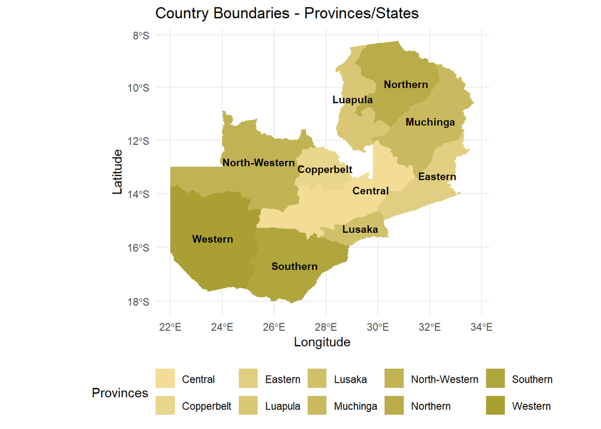

```r
ggplot() +
  geom_sf(data = country_boundaries, aes(fill = as.factor(province)), color = NA) +
  geom_sf_text(data = country_boundaries, aes(label = province), size = 3, color = "black", fontface = "bold") +
  scale_fill_manual(values = colorRampPalette(c("#F2DC96", "#A99F33"))(length(unique(country_boundaries$province)))) +
  labs(title = "Country Boundaries - Provinces/States",
       x = "Longitude",
       y = "Latitude",
       fill = "Provinces") +
  theme_minimal() +
  theme(legend.position = "bottom")
```

Selecting and organizing target TSUs for analysis. In our example, we are working with two provinces and one type of land-use. However, for projects like SoilFER, which operate on a national scale, the code can easily be scaled to more provinces and land-use categories.

`filter()` function filters the dataset to include only TSUs marked as Target for both `SSU_Type` and `TSU_Type`. `st_join()` function joins the TSUs with the `country_boundaries` shapefile to add geographic context.

```r
tsus_uniq_sites <- dplyr::filter(tsus_target_croplands, SSU_Type == "Target" & TSU_Type == "Target")
head(tsus_uniq_sites, 5)
```

```
## Simple feature collection with 5 features and 9 fields
## Geometry type: POINT
## Dimension:     XY
## Bounding box:  xmin: 3448175 ymin: -1614852 xmax: 3451411 ymax: -1611824
## Projected CRS: WGS 84 / Pseudo-Mercator
##   PSU_ID PSU_Type SSU_ID SSU_Type TSU_ID TSU_Type      site_id lulc Replace_ID
## 1      1   Target      1   Target      1   Target ZMB0001-1-1C    C         27
## 2      1   Target      2   Target      1   Target ZMB0001-2-1C    C         27
## 3      1   Target      3   Target      1   Target ZMB0001-3-1C    C         27
## 4      1   Target      4   Target      1   Target ZMB0001-4-1C    C         27
## 5      2   Target      1   Target      1   Target ZMB0002-1-1C    C         28
##                   geometry
## 1 POINT (3451411 -1614238)
## 2 POINT (3450113 -1614852)
## 3 POINT (3450319 -1614682)
## 4 POINT (3450628 -1614725)
## 5 POINT (3448175 -1611824)
```

```r
tsus_uniq_sites <- sf::st_join(tsus_uniq_sites, country_boundaries)
tsus_uniq_sites <- tsus_uniq_sites %>%
  select(c(site_id, country, province, lulc, geometry))

# Converting shapefile to DF
tsus_uniq_sites_df <- as.data.frame(tsus_uniq_sites)

sites_distribution <- tsus_uniq_sites_df %>%
  group_by(country, lulc) %>%
  summarise(Sites = n())
```

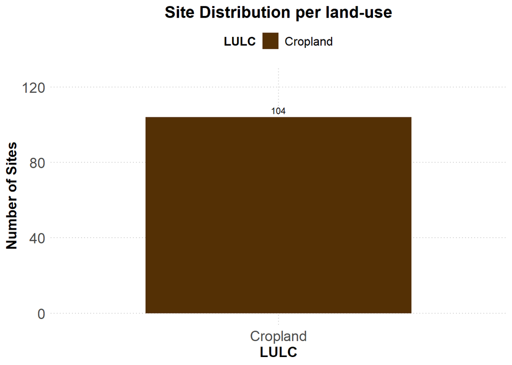

```r
custom_colors <- colorRampPalette(brewer.pal(11, "BrBG"))(ncolors)

#jpeg(paste0(folder,"/final_site_distribution.jpeg"), width = 16, height = 12, units = 'in', res = 300)
ggplot(sites_distribution, aes(x = lulc, y = Sites, fill = lulc)) +
  geom_bar(stat = "identity", position = "dodge", width = 0.7) +
  geom_text(aes(label = Sites),
            position = position_dodge(width = 0.7),
            vjust = -0.5, size = 3) +
  labs(
    title = "Site Distribution per land-use",
    x = "LULC",
    y = "Number of Sites",
    fill = "LULC"
  ) +
  scale_x_discrete(labels = c("C" = "Cropland", "F" = "Forest", "G" = "Grassland")) +  # Rename x-axis labels
  scale_fill_manual(values = custom_colors, labels = c("C" = "Cropland", "F" = "Forest", "G" = "Grassland")) +  # Custom color palette
  ylim(0, max(sites_distribution$Sites) * 1.2) +
  theme_minimal() +
  theme(
    plot.title = element_text(hjust = 0.5, size = 16, face = "bold"),
    axis.text.x = element_text(angle = 0, hjust = 0.5, size = 14),
    axis.text.y = element_text(size = 14),
    axis.title.x = element_text(size = 14, face = "bold"),
    axis.title.y = element_text(size = 14, face = "bold"),
    legend.position = "top",
    legend.title = element_text(size = 12, face = "bold"),
    legend.text = element_text(size = 12),
    panel.grid.major = element_line(color = "grey80", linetype = "dotted"),
    panel.grid.minor = element_blank()
  )
```

```r
#dev.off()
```

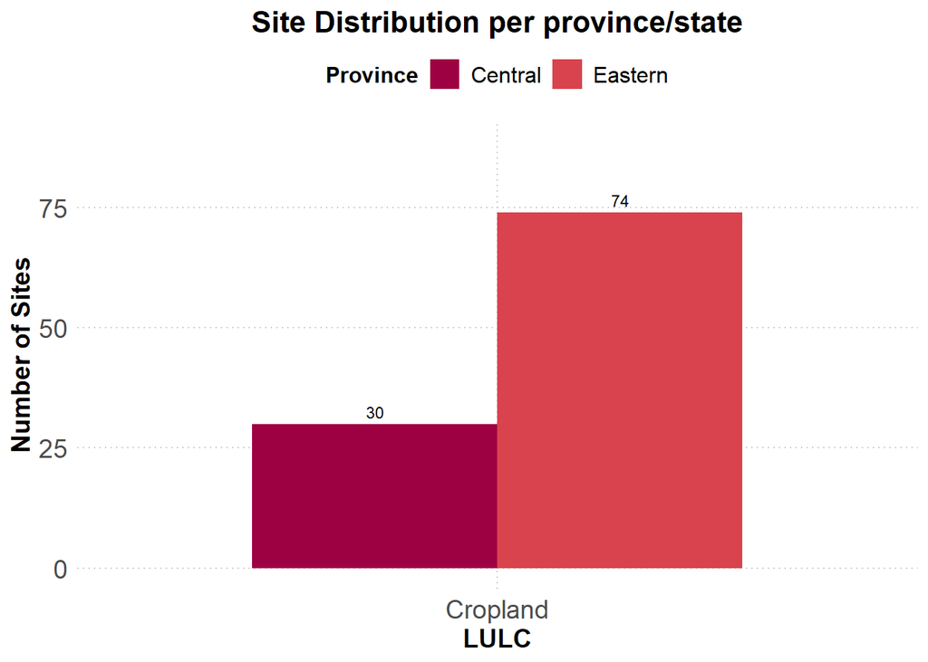

```r
tsus_uniq_sites_df <- as.data.frame(tsus_uniq_sites)
sites_distribution <- tsus_uniq_sites_df %>%
  group_by(province, lulc) %>%
  summarise(Sites = n())

# Graphs
custom_colors <- colorRampPalette(brewer.pal(11, "Spectral"))(ncolors)

#jpeg(paste0(folder,"/final_site_distribution_province.jpeg"), width = 16, height = 12, units = 'in', res = 300)
ggplot(sites_distribution, aes(x = lulc, y = Sites, fill = province)) +
  geom_bar(stat = "identity", position = "dodge", width = 0.7) +
  geom_text(aes(label = Sites),
            position = position_dodge(width = 0.7),
            vjust = -0.5, size = 3) +
  labs(
    title = "Site Distribution per province/state",
    x = "LULC",
    y = "Number of Sites",
    fill = "Province"
  ) +
  scale_x_discrete(labels = c("C" = "Cropland", "F" = "Forest", "G" = "Grassland")) +  # Rename x-axis labels
  scale_fill_manual(values = custom_colors) +  # Custom color palette
  ylim(0, max(sites_distribution$Sites) * 1.2) +
  theme_minimal() +
  theme(
    plot.title = element_text(hjust = 0.5, size = 16, face = "bold"),
    axis.text.x = element_text(angle = 0, hjust = 0.5, size = 14),
    axis.text.y = element_text(size = 14),
    axis.title.x = element_text(size = 14, face = "bold"),
    axis.title.y = element_text(size = 14, face = "bold"),
    legend.position = "top",
    legend.title = element_text(size = 12, face = "bold"),
    legend.text = element_text(size = 12),
    panel.grid.major = element_line(color = "grey80", linetype = "dotted"),
    panel.grid.minor = element_blank()
  )
```

```r
#dev.off()
```